# Final Exam_Data and Programming for Analytics_2021Fall

## Data and Programming for Analytics Final 2021

- Time: 8am PST (Monday, December 6, 2021) to 8am PST (Wednesday, December 8, 2021)
- Submission: please upload both .ipynb file and .html file on Canvas under Assignments -> Final
- You are required to answer all questions.
- This is a “open book, open computer” exam
- You should solve those problems on your own. You are allowed to "google" or do your own research on the internet, but you are not allowed to seek help from others, including but not limited to family members, friends, classmates and so forth.
- Please be as succinct as possible in answering the questions.
- The total score is 130 points.

### Please initial here that if you agree to comply to the UCI Academic Honesty Policy:**PPK*__***

### Part I. Multiple Choices and Short-Answer Questions (40 pts)

#### Q1.

Which of the following has a different number of iterations?

```python
#a)
i = 0
while i <=100:
    i = i+1
```

```python
i = 0
while i <=100:
    i = i+1

print(i)
```

```
101
```

```python
#b)
for i in range(100):
    print("Hi")
```

```python
k = 0
for i in range(100):
    #print("Hi")
    k = k + 1
print(k)
```

```
100
```

```python
#c)
j=0
for i in range(100, 0, -1):
    #print("Hi")
    j = j + 1
print(j)
```

```
100
```

```python
#d)
l=0
i=100
while (i>0):
    #print("Hi")
    i = i-1
    l = l+1
print(l)
```

```
100
```

# Your Answer Here:

Option a) is the one which has a different number of iterations. It does 101 iterations where as the others do 100 iterations. i = 0 while i <=100: i = i+1

#### Q2.

Write a list comprehension to take in a list and transform each word into its uppercase and also calculate the length of the word.

str1 =["Merage", "Python", "programming"]

Expected output: [('MERAGE', 6), ('PYTHON', 6), ('PROGRAMMING', 11)]

```python
# Your Answer Here:
str1 =["Merage", "Python", "programming"]

print([(i.upper(),len(i)) for i in str1])
```

```
[('MERAGE', 6), ('PYTHON', 6), ('PROGRAMMING', 11)]
```

#### Q3.

How many iterations the following while loop will run (we assume we use Python 3.x)?

```python
num_of_iter = 0
i = 1000
while i >1:
    i = i/2
    num_of_iter = num_of_iter + 1
print(num_of_iter)
```

```
10
```

a) 500

b) 10

c) 499

d) 9

e) 1001

# Your Answer Here:

The above while loop ran b) 10 times

#### Q4.

Write a program which will find all such numbers which are divisible by 6 but are not a multiple of 5, between 1000 and 2000 (both included).

The numbers obtained should be printed in a comma-separated sequence on a single line, such as n1, n2, n3, ...

```python
# Your Solution Here:
for i in range(1000,2001):
    if((i%6 == 0) and (i%5 != 0)):
        print(str(i), end=", ")
```

```
1002, 1008, 1014, 1026, 1032, 1038, 1044, 1056, 1062, 1068, 1074, 1086, 1092, 1098, 1104, 1116, 1122, 1128, 1134, 1146, 1152, 1158, 1164, 1176, 1182, 1188, 1194, 1206, 1212, 1218, 1224, 1236, 1242, 1248, 1254, 1266, 1272, 1278, 1284, 1296, 1302, 1308, 1314, 1326, 1332, 1338, 1344, 1356, 1362, 1368, …
```

#### Q5.

Write a program that accepts a sequence of whitespace separated words as input and prints the words after removing all duplicate words and sorting them alphanumerically.

Example input:

Do not go where the path may lead, go instead where there is no path and leave a trail.

Example output:

Do a and go instead is lead, leave may no not path the there trail. where

```python
if __name__ == "__main__":
    s = input()
    answer = list(dict.fromkeys(s.split()).keys())
    print(" ".join(sorted(answer)))
```

```
Do not go where the path may lead, go instead where there is no path and leave a trail.
Do a and go instead is lead, leave may no not path the there trail. where
```

#### Q6.

Given a string, return the sum and average of the digits that appear in the string, ignoring all other characters.

Given:

str1 = "Data Analytics = 95 Economics = 85 Marketing = 90"

Expected Outcome:

Sum: 270

Average: 90

```python
l = []
str1 = "Data Analytics = 95 Economics = 85 Marketing = 90"
for t in str1.split():
    try:
        l.append(int(t))
    except ValueError:
        pass

print("Sum: " + str(sum(l)))

print("Average: " + str(int(sum(l) / len(l))))
```

```
Sum: 270
Average: 90
```

#### Q7.

Turn the following dictionaries into data frames then combine them into a 2x4 (two rows, 4 columns) such that the column names are the animal names.

dict_1 = {"Cows":[40, 20], "Sheep":[22, 21]}

dict_2 = {"Pig":[12, 4], "Crow":[60, 10]}

```python
import pandas as pd

dict_1 = {"Cows":[40, 20], "Sheep":[22, 21]}
dict_2 = {"Pig":[12, 4], "Crow":[60, 10]}

df_1 = pd.DataFrame(dict_1)
df_2 = pd.DataFrame(dict_2)

pd.concat([df_1,df_2],axis=1)
```

|  | Cows | Sheep | Pig | Crow |
| --- | --- | --- | --- | --- |
| 0 | 40 | 22 | 12 | 60 |
| 1 | 20 | 21 | 4 | 10 |

#### Q8.

Reverse words in the string "one apple a day keeps the doctors away" and print the new string

```python
str1 = "one apple a day keeps the doctors away"

words = str1.split(' ')

reverse_sentence = ' '.join(reversed(words))

print(reverse_sentence)
```

```
away doctors the keeps day a apple one
```

### Part II. Iterating Loops (20 pts)

Write a program that takes in 3 comma separated integers (ex. 500, 4, 14) and puts them into a list for use. Each number will be used for the range() function as the incrementing factor for a starting point of 0 to a stopping point of 2000. The range() function is in the form of range(start, stop, step), where step is the incrementing factor. Print out a list containing tuples that have the each input and total iterations like this:

[(, ), (, ), (, )]

Please use list comprehension only instead of for loops for this problem.

For example:

Input: 2, 16, 228

You will be using each of these numbers as the step in the range function. The range will begin at 0 and end at 2000. For step = 2, the total number of iterations is 1000. For step = 16, the total number of iterations is 125. For step = 228, the total number of iterations is 9.

Now the question states you to save each input and its total number of iterations within a tuple that is within a list.

Thus your final answer is [(2, 1000), (16, 125), (228, 9)]

Example Input: 14, 3, 4000

Example Output: [(14, 143), (3, 667), (4000, 1)]

```python
# Your Solution Here:
comma_sep_integers = input()
list_of_int = comma_sep_integers.split(", ")

answer = [(int(i),len(range(0, 2000, int(i)))) for i in list_of_int]
print(answer)
```

```
2, 16, 228
[(2, 1000), (16, 125), (228, 9)]
```

### Part III. Login Information (30 pts)

Your boss wants you to create a program that can take a user's email from their biography, create a password for the user, and save it into a dictionary for later use. The email will be in the form alphabetic@uci.edu (no numbers, all lowercase). The username is the characters before the domain name (ie. johnsmith in the email johnsmith@uci.edu). To create the password, you need to alter the username with ROT13.

ROT13 (rotate by 13 places) is a simple substitution cipher that replaces a letter with the 13th letter after it in the alphabet. For example, "j" is the 10th letter in the alphabet. Altering "j" with ROT13 will get the 23rd (10 + 13 = 23) letter of the alphabet, "w". Likewise, if you altered "w" with ROT13, you will get the 10th (23 + 13 = 46 - 26 = 10) letter of the alphabet, "j". Thus in our example with johnsmith@uci.edu, the password will be "wbuafzvgu". Save both the username and password in a dictionary.

Input:

The input will be several sentences on a single line containing exactly one email within the biography with the form: alphabetic@uci.edu.

Output:

Print your dictionary which contains "username": and "password":

```python
#Example Input:
str_input = "Tingting Nian, Assistant Professor at The Paul Merage School of Business at University of California, Irvine, studies social media, online communities and economics of digital goods. Her prior research has won the 2014 INFORMS Conference on Information Systems and Technology Best Conference Paper Award and a WCAI Research Award from Wharton Customer Analytics Initiative. Her email is tnian@uci.edu. She received her PhD in Business Administration (specialized in Information Systems) from Leonard N. Stern School of Business at NYU in 2015 and holds a Bachelor’s degree in Business Administration from Tsinghua University."
```

```python
#Example Output:
{'username':'tnian', 'password':'gavna'}
```

```python
#Solution Here:
def rot13(s):
    chars = "abcdefghijklmnopqrstuvwxyz"
    trans = chars[13:]+chars[:13]
    rot_char = lambda c: trans[chars.find(c)] if chars.find(c)>-1 else c
    return ''.join( rot_char(c) for c in s )
dict_of_pass = dict()
import re
emails = re.findall(r"[a-z0-9\.\-+_]+@[a-z0-9\.\-+_]+\.[a-z]+", str_input)

dict_of_pass["username"] = emails[0].split("@")[0]
dict_of_pass["password"] = rot13(emails[0].split("@")[0])



print(dict_of_pass)
```

```
{'username': 'tnian', 'password': 'gavna'}
```

### Part IV. Data Analysis (40 pts)

Please generate some analyses and visualization using the crunchbase dataset you downloaded from Canvas. Feel free to use any packages (in Python), and generate any types of figures. You may also comment on the generated results and figures, and explain any insights you have obtained.

```python
import pandas as pd
import numpy as np

import datetime
import matplotlib

%matplotlib inline
```

```python
df_acquisitions = pd.read_csv("crunchbase_acquisitions.csv")
df_companies = pd.read_csv("crunchbase_companies.csv")
df_investments = pd.read_csv("crunchbase_investments.csv")
```

Check the presence of missing values for the further analysis

```python
df_companies.isnull().sum()
```

```
permalink                0
name                     0
homepage_url          1387
category_code         1029
funding_total_usd     3317
status                   0
country_code          1823
state_code           10455
region                   0
city                  2622
funding_rounds           0
founded_at            5886
founded_at_clean      5886
id                       0
dtype: int64
```

```python
df_acquisitions.isnull().sum()
```

```
company_permalink            0
acquirer_permalink           0
acquirer_name                0
acquirer_category_code     915
acquirer_country_code      522
acquirer_state_code       1939
acquirer_region              0
acquirer_city              731
price_amount              5372
price_currency_code          4
acquired_at                  0
acquired_at_cleaned          0
id                           0
dtype: int64
```

```python
df_investments.isnull().sum()
```

```
company_permalink             0
company_name                  0
company_category_code      1609
company_country_code       3048
company_state_code        24677
company_region                0
company_city               4919
investor_permalink            0
investor_name                 0
investor_category_code    79428
investor_country_code     19989
investor_state_code       38390
investor_region               0
investor_city             21240
funding_round_type            1
funded_at                     1
funded_month                  1
funded_quarter                1
funded_year                   1
raised_amount_usd          8118
id                            0
dtype: int64
```

#### Rank the total funding amount by category

- Goal: identify top 3 startup categories for further analysis
- What insights can you generate from this analysis?
- Hints: when you join these tables together, you may use investor_permalink, company_permalink.

```python
df_companies.groupby(["category_code"])["funding_total_usd"].sum().sort_values(ascending=False).head(5)
```

```
category_code
biotech       5.659751e+10
software      3.341639e+10
cleantech     3.313164e+10
mobile        2.667997e+10
enterprise    1.766521e+10
Name: funding_total_usd, dtype: float64
```

```python
df_investments.groupby(["company_category_code"])["raised_amount_usd"].sum().sort_values(ascending=False).head(5)
```

```
company_category_code
biotech       1.499328e+11
software      9.824902e+10
mobile        8.189248e+10
cleantech     7.105269e+10
enterprise    5.809240e+10
Name: raised_amount_usd, dtype: float64
```

From the above tables we can see that biotech, software and mobiles are the top 3 startup categories if we take the df_investments dataframe into account and use the raised amount. On the other hand if we use the df_companies dataframe and the total funding we can see that biotech, software and cleantech are the top 3 startup categories.

#### Identify top-10 investors in biotech, software, and cleantech

- Goal: identify top-10 investors in the most funded startup categories
- What insights can you generate from this analysis?

```python
df_investments_biotech = df_investments[df_investments["company_category_code"]=="biotech"]
df_investments_software = df_investments[df_investments["company_category_code"]=="software"]
df_investments_cleantech = df_investments[df_investments["company_category_code"]=="cleantech"]
pd.set_option("display.max_row",None)
df_investments_biotech.groupby(["investor_name"])["raised_amount_usd"].sum().sort_values(ascending=False).head(10)
```

```
investor_name
Domain Associates                            2.102790e+09
OrbiMed Advisors                             2.040800e+09
New Enterprise Associates                    1.945754e+09
Alta Partners                                1.902820e+09
Novartis Venture Fund                        1.821610e+09
Kleiner Perkins Caufield & Byers             1.719642e+09
MPM Capital                                  1.684000e+09
Novo A/S                                     1.531524e+09
Johnson & Johnson Development Corporation    1.426701e+09
New Leaf Venture Partners                    1.369238e+09
Name: raised_amount_usd, dtype: float64
```

```python
df_investments_software.groupby(["investor_name"])["raised_amount_usd"].sum().sort_values(ascending=False).head(10)
```

```
investor_name
Intel Capital                1.484950e+09
Accel Partners               1.480640e+09
Benchmark                    1.427275e+09
Sequoia Capital              1.272350e+09
New Enterprise Associates    1.123100e+09
Goldman Sachs                1.107100e+09
Insight Venture Partners     1.089100e+09
Greylock Partners            9.507500e+08
Index Ventures               8.108639e+08
Redpoint Ventures            7.829500e+08
Name: raised_amount_usd, dtype: float64
```

In the Software sector, the top 10 investors are given above. We can see that Intel Capital has the highest investment and the amount they have spent is nearly twice that of the 10th place investor Redpoint Ventures. Intel Capital and Accel Partners have spent nearly the same amount though. On average, the top 10 investors in software have spent less than the top 10 investors in biotech.

```python
df_investments_cleantech.groupby(["investor_name"])["raised_amount_usd"].sum().sort_values(ascending=False).head(10)
```

```
investor_name
Kleiner Perkins Caufield & Byers    2.647800e+09
Khosla Ventures                     1.870570e+09
VantagePoint Capital Partners       1.560486e+09
New Enterprise Associates           1.240180e+09
Draper Fisher Jurvetson (DFJ)       8.061350e+08
Morgan Stanley                      7.737000e+08
Goldman Sachs                       6.699000e+08
Denham Capital                      6.500000e+08
Oak Investment Partners             6.451000e+08
NGEN Partners                       6.382000e+08
Name: raised_amount_usd, dtype: float64
```

#### Study the investment strategies of top-10 cleantech investors

- Goal: generate insights on the investment strategies of top-5 cleantech investors (e.g. different investors may have different preferences for specific funding round such as series-a, series-b, series-c, venture funding, and etc.)

```python
df_investments_cleantech_kleiner = df_investments_cleantech[df_investments_cleantech["investor_name"]=="Kleiner Perkins Caufield & Byers"]
df_investments_cleantech_khosla = df_investments_cleantech[df_investments_cleantech["investor_name"]=="Khosla Ventures"]
df_investments_cleantech_vantage = df_investments_cleantech[df_investments_cleantech["investor_name"]=="VantagePoint Capital Partners"]
df_investments_cleantech_newenter = df_investments_cleantech[df_investments_cleantech["investor_name"]=="New Enterprise Associates"]
df_investments_cleantech_draper = df_investments_cleantech[df_investments_cleantech["investor_name"]=="Draper Fisher Jurvetson (DFJ)"]
```

```python
pd.set_option("display.max_columns",None)
df_investments_cleantech_kleiner.groupby("funding_round_type").count()
```

| funding_round_type | company_permalink | company_name | company_category_code | company_country_code | company_state_code | company_region | company_city | investor_permalink | investor_name | investor_category_code | investor_country_code | investor_state_code | investor_region | investor_city | funded_at | funded_month | funded_quarter | funded_year | raised_amount_usd | id |
| --- | --- | --- | --- | --- | --- | --- | --- | --- | --- | --- | --- | --- | --- | --- | --- | --- | --- | --- | --- | --- |
| other | 1 | 1 | 1 | 1 | 1 | 1 | 1 | 1 | 1 | 0 | 1 | 1 | 1 | 1 | 1 | 1 | 1 | 1 | 1 | 1 |
| private-equity | 1 | 1 | 1 | 1 | 1 | 1 | 1 | 1 | 1 | 0 | 1 | 1 | 1 | 1 | 1 | 1 | 1 | 1 | 1 | 1 |
| series-a | 5 | 5 | 5 | 5 | 5 | 5 | 5 | 5 | 5 | 0 | 5 | 5 | 5 | 5 | 5 | 5 | 5 | 5 | 5 | 5 |
| series-b | 12 | 12 | 12 | 12 | 12 | 12 | 12 | 12 | 12 | 0 | 12 | 12 | 12 | 12 | 12 | 12 | 12 | 12 | 12 | 12 |
| series-c+ | 18 | 18 | 18 | 18 | 18 | 18 | 18 | 18 | 18 | 0 | 18 | 18 | 18 | 18 | 18 | 18 | 18 | 18 | 18 | 18 |
| venture | 18 | 18 | 18 | 18 | 17 | 18 | 18 | 18 | 18 | 0 | 18 | 18 | 18 | 18 | 18 | 18 | 18 | 18 | 15 | 18 |

Kleiner Perkins Caufield & Byers seems to like venture and series-c+ funding rounds

```python
df_investments_cleantech_khosla.groupby("funding_round_type").count()
```

| funding_round_type | company_permalink | company_name | company_category_code | company_country_code | company_state_code | company_region | company_city | investor_permalink | investor_name | investor_category_code | investor_country_code | investor_state_code | investor_region | investor_city | funded_at | funded_month | funded_quarter | funded_year | raised_amount_usd | id |
| --- | --- | --- | --- | --- | --- | --- | --- | --- | --- | --- | --- | --- | --- | --- | --- | --- | --- | --- | --- | --- |
| other | 2 | 2 | 2 | 2 | 2 | 2 | 2 | 2 | 2 | 0 | 2 | 2 | 2 | 2 | 2 | 2 | 2 | 2 | 2 | 2 |
| private-equity | 1 | 1 | 1 | 1 | 1 | 1 | 1 | 1 | 1 | 0 | 1 | 1 | 1 | 1 | 1 | 1 | 1 | 1 | 1 | 1 |
| series-a | 8 | 8 | 8 | 8 | 8 | 8 | 8 | 8 | 8 | 0 | 8 | 8 | 8 | 8 | 8 | 8 | 8 | 8 | 8 | 8 |
| series-b | 17 | 17 | 17 | 17 | 17 | 17 | 17 | 17 | 17 | 0 | 17 | 17 | 17 | 17 | 17 | 17 | 17 | 17 | 17 | 17 |
| series-c+ | 20 | 20 | 20 | 20 | 20 | 20 | 20 | 20 | 20 | 0 | 20 | 20 | 20 | 20 | 20 | 20 | 20 | 20 | 19 | 20 |
| venture | 15 | 15 | 15 | 13 | 13 | 15 | 13 | 15 | 15 | 0 | 15 | 15 | 15 | 15 | 15 | 15 | 15 | 15 | 14 | 15 |

Khosla Ventures on the other hand likes the series-c+ funding round and then the series-b round with venture being in third place.

```python
df_investments_cleantech_vantage.groupby("funding_round_type").count()
```

| funding_round_type | company_permalink | company_name | company_category_code | company_country_code | company_state_code | company_region | company_city | investor_permalink | investor_name | investor_category_code | investor_country_code | investor_state_code | investor_region | investor_city | funded_at | funded_month | funded_quarter | funded_year | raised_amount_usd | id |
| --- | --- | --- | --- | --- | --- | --- | --- | --- | --- | --- | --- | --- | --- | --- | --- | --- | --- | --- | --- | --- |
| other | 1 | 1 | 1 | 1 | 1 | 1 | 1 | 1 | 1 | 0 | 1 | 1 | 1 | 1 | 1 | 1 | 1 | 1 | 1 | 1 |
| private-equity | 2 | 2 | 2 | 2 | 2 | 2 | 2 | 2 | 2 | 0 | 2 | 2 | 2 | 2 | 2 | 2 | 2 | 2 | 2 | 2 |
| series-a | 4 | 4 | 4 | 3 | 2 | 4 | 3 | 4 | 4 | 0 | 4 | 4 | 4 | 4 | 4 | 4 | 4 | 4 | 3 | 4 |
| series-b | 5 | 5 | 5 | 5 | 3 | 5 | 5 | 5 | 5 | 0 | 5 | 5 | 5 | 5 | 5 | 5 | 5 | 5 | 5 | 5 |
| series-c+ | 12 | 12 | 12 | 12 | 12 | 12 | 12 | 12 | 12 | 0 | 12 | 12 | 12 | 12 | 12 | 12 | 12 | 12 | 12 | 12 |
| venture | 5 | 5 | 5 | 5 | 2 | 5 | 5 | 5 | 5 | 0 | 5 | 5 | 5 | 5 | 5 | 5 | 5 | 5 | 5 | 5 |

VantagePoint Capital Partners like the series-c+ funding round the most.

```python
df_investments_cleantech_newenter.groupby("funding_round_type").count()
```

| funding_round_type | company_permalink | company_name | company_category_code | company_country_code | company_state_code | company_region | company_city | investor_permalink | investor_name | investor_category_code | investor_country_code | investor_state_code | investor_region | investor_city | funded_at | funded_month | funded_quarter | funded_year | raised_amount_usd | id |
| --- | --- | --- | --- | --- | --- | --- | --- | --- | --- | --- | --- | --- | --- | --- | --- | --- | --- | --- | --- | --- |
| private-equity | 2 | 2 | 2 | 2 | 1 | 2 | 2 | 2 | 2 | 0 | 2 | 2 | 2 | 2 | 2 | 2 | 2 | 2 | 2 | 2 |
| series-a | 6 | 6 | 6 | 6 | 6 | 6 | 6 | 6 | 6 | 0 | 6 | 6 | 6 | 6 | 6 | 6 | 6 | 6 | 6 | 6 |
| series-b | 9 | 9 | 9 | 9 | 9 | 9 | 9 | 9 | 9 | 0 | 9 | 9 | 9 | 9 | 9 | 9 | 9 | 9 | 9 | 9 |
| series-c+ | 8 | 8 | 8 | 8 | 8 | 8 | 8 | 8 | 8 | 0 | 8 | 8 | 8 | 8 | 8 | 8 | 8 | 8 | 8 | 8 |
| venture | 6 | 6 | 6 | 6 | 6 | 6 | 6 | 6 | 6 | 0 | 6 | 6 | 6 | 6 | 6 | 6 | 6 | 6 | 6 | 6 |

New Enterprise Associates does not seem to have a extremely high preference for any funding round but usually goes for series-b with series-c+ being the second most used

```python
df_investments_cleantech_draper.groupby("funding_round_type").count()
```

| funding_round_type | company_permalink | company_name | company_category_code | company_country_code | company_state_code | company_region | company_city | investor_permalink | investor_name | investor_category_code | investor_country_code | investor_state_code | investor_region | investor_city | funded_at | funded_month | funded_quarter | funded_year | raised_amount_usd | id |
| --- | --- | --- | --- | --- | --- | --- | --- | --- | --- | --- | --- | --- | --- | --- | --- | --- | --- | --- | --- | --- |
| private-equity | 1 | 1 | 1 | 1 | 1 | 1 | 1 | 1 | 1 | 0 | 1 | 1 | 1 | 1 | 1 | 1 | 1 | 1 | 1 | 1 |
| series-a | 7 | 7 | 7 | 7 | 6 | 7 | 7 | 7 | 7 | 0 | 7 | 7 | 7 | 7 | 7 | 7 | 7 | 7 | 6 | 7 |
| series-b | 5 | 5 | 5 | 5 | 4 | 5 | 5 | 5 | 5 | 0 | 5 | 5 | 5 | 5 | 5 | 5 | 5 | 5 | 5 | 5 |
| series-c+ | 9 | 9 | 9 | 8 | 7 | 9 | 8 | 9 | 9 | 0 | 9 | 9 | 9 | 9 | 9 | 9 | 9 | 9 | 9 | 9 |
| venture | 18 | 18 | 18 | 17 | 13 | 18 | 17 | 18 | 18 | 0 | 18 | 18 | 18 | 18 | 18 | 18 | 18 | 18 | 18 | 18 |

Draper Fisher Jurvetson (DFJ) prefers the venture round on the other hand with series-c+ being in second place.

#### What other insights you may find from this dataset (open-ended question). Feel free to use any type of analysis in this part.

```python
df_investments.columns
```

```
Index(['company_permalink', 'company_name', 'company_category_code',
       'company_country_code', 'company_state_code', 'company_region',
       'company_city', 'investor_permalink', 'investor_name',
       'investor_category_code', 'investor_country_code',
       'investor_state_code', 'investor_region', 'investor_city',
       'funding_round_type', 'funded_at', 'funded_month', 'funded_quarter',
       'funded_year', 'raised_amount_usd', 'id'],
      dtype='object')
```

```python
df_investments.describe()
```

|  | funded_year | raised_amount_usd | id |
| --- | --- | --- | --- |
| count | 83892.000000 | 7.577500e+04 | 83893.000000 |
| mean | 2009.965444 | 1.273083e+07 | 41947.000000 |
| std | 2.769831 | 4.229933e+07 | 24217.967404 |
| min | 1974.000000 | 1.000000e+03 | 1.000000 |
| 25% | 2008.000000 | 1.500000e+06 | 20974.000000 |
| 50% | 2011.000000 | 5.270000e+06 | 41947.000000 |
| 75% | 2012.000000 | 1.400000e+07 | 62920.000000 |
| max | 2014.000000 | 3.200000e+09 | 83893.000000 |

We can see that this is a dataset which encompasses investments between 1974 and 2014, but that most of the records are after 2008. We can also see that the average raised amount is 1.27e07 dollars but that the median raised amount is 5.27e06 dollars. This shows that the dataset has got quite a few high values of raised amount which is skewing the average raised amount values.

# Startups compared across eras

```python
def year_group(row):
    if row['funded_year'] >= 1900 and row['funded_year'] <= 2002:
        row['funded_year_group'] = 'less_than_2000'
    elif row['funded_year'] > 2002 and row['funded_year'] <= 2005:
        row['funded_year_group'] = '2002_2005'
    elif row['funded_year'] > 2005 and row['funded_year'] <= 2008:
        row['funded_year_group'] = '2005_2008'
    elif row['funded_year'] > 2008 and row['funded_year'] <= 2011:
        row['funded_year_group'] = '2008_2011'
    elif row['funded_year'] > 2011:
        row['funded_year_group'] = '2011_2014'
    else:
        row['funded_year_group'] = ''
    return row['funded_year_group']

df_investments['funded_year_group'] =  df_investments.apply(year_group,axis =1)
```

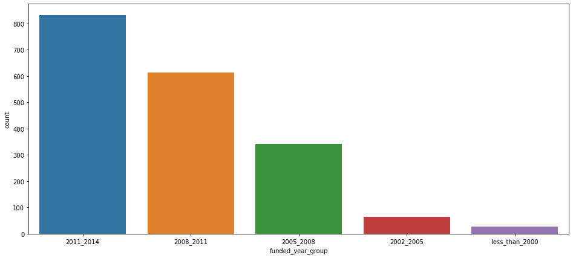

```python
import matplotlib.pyplot as plt
import seaborn as sns
plt.figure(figsize = (16,7))
sns.countplot(x = 'funded_year_group', data = df_investments.dropna())
plt.show()
```

We can see that most of the startups in the dataset are between 2011 and 2014 with the second most representatives coming in between 2008 and 2011. We can see that with time the number of start ups has just increased.

# Startups since 2000

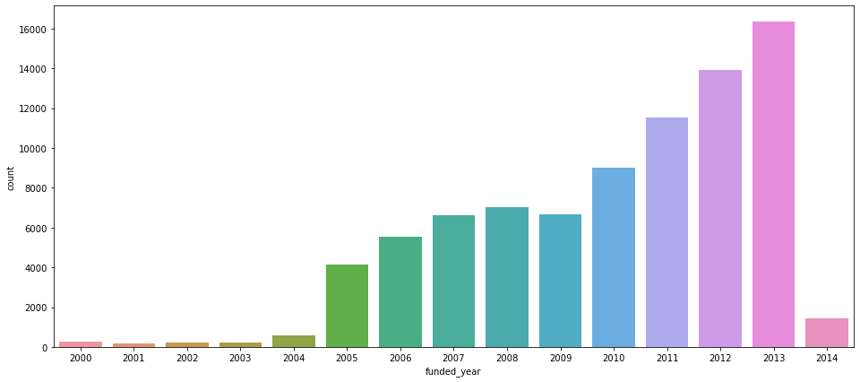

```python
df_new = df_investments[df_investments['funded_year'] >= 2000]
df_new['funded_year'] = df_new['funded_year'].astype(int)
plt.figure(figsize = (16,7))
sns.countplot(x = 'funded_year', data = df_new)
plt.show()
```

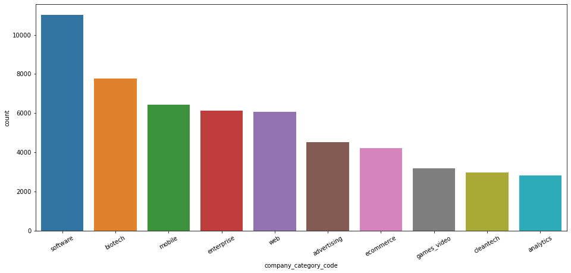

```python
plt.figure(figsize=(16,7))
sns.countplot(x ='company_category_code', data = df_investments, order=df_investments['company_category_code'].value_counts().iloc[:10].index)
plt.xticks(rotation=30)
plt.show()
```

We can see that the software, biotech and mobile sectors are the company categories which are the most represented.

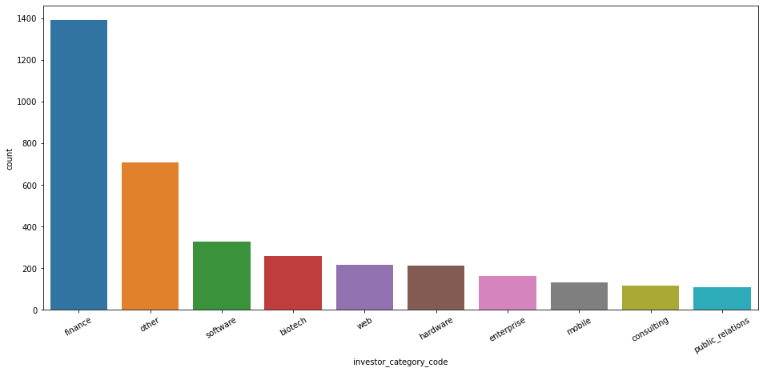

```python
plt.figure(figsize=(16,7))
sns.countplot(x ='investor_category_code', data = df_investments, order=df_investments['investor_category_code'].value_counts().iloc[:10].index)
plt.xticks(rotation=30)
plt.show()
```

We can see that the finance, other and software sectors are the investor categories which are the most represented.

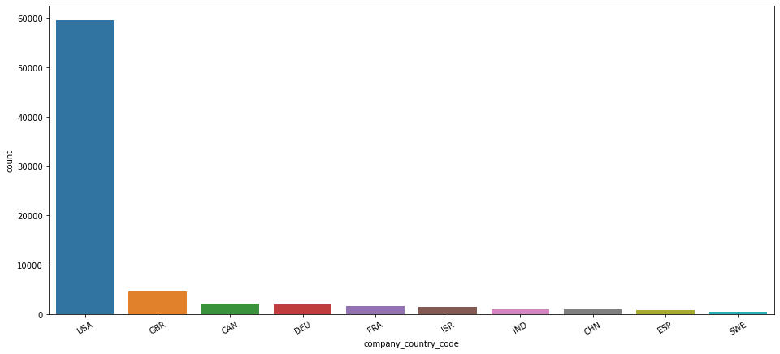

```python
plt.figure(figsize=(16,7))
g = sns.countplot(x ='company_country_code', data = df_investments, order=df_investments['company_country_code'].value_counts().iloc[:10].index)
plt.xticks(rotation=30)
plt.show()
```

We can see that the US, GBR and CAN are the countries which are most represented among the companies.

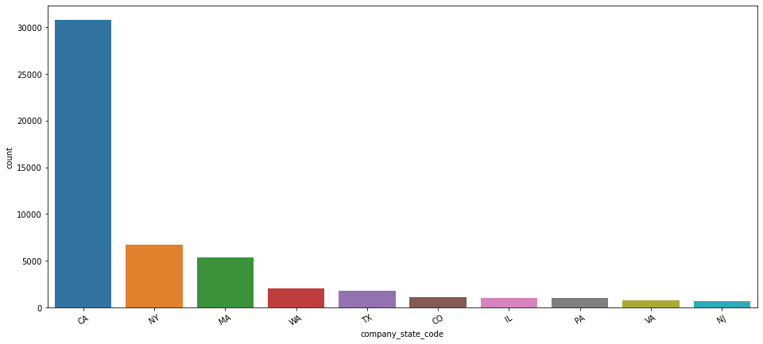

```python
plt.figure(figsize=(16,7))
g = sns.countplot(x ='company_state_code', data = df_investments, order=df_investments['company_state_code'].value_counts().iloc[:10].index)
plt.xticks(rotation=30)
plt.show()
```

We can see that California is the most represented state among the companies followed by NY and then MA and WA.

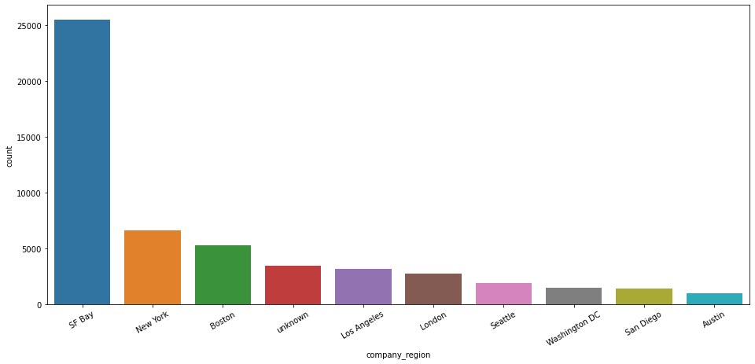

```python
plt.figure(figsize=(16,7))
g = sns.countplot(x ='company_region', data = df_investments, order=df_investments['company_region'].value_counts().iloc[:10].index)
plt.xticks(rotation=30)
plt.show()
```

We can see that the SF Bay is the most represented among the companies followed by New York, Boston and unknown.

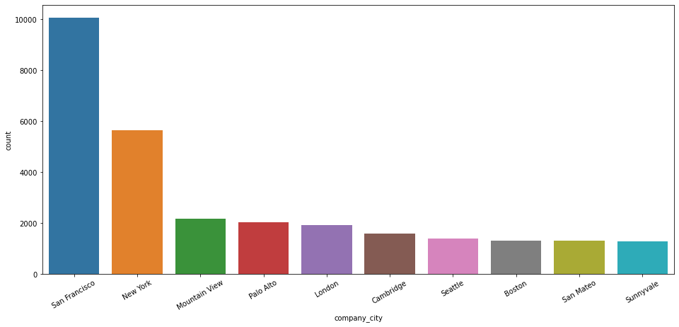

```python
plt.figure(figsize=(16,7))
g = sns.countplot(x ='company_city', data = df_investments, order=df_investments['company_city'].value_counts().iloc[:10].index)
plt.xticks(rotation=30)
plt.show()
```

We can see that San Francisco is the most represented among the cities followed by New York and then Mountain View and Palo Alto. Later we have the first foreign city London.

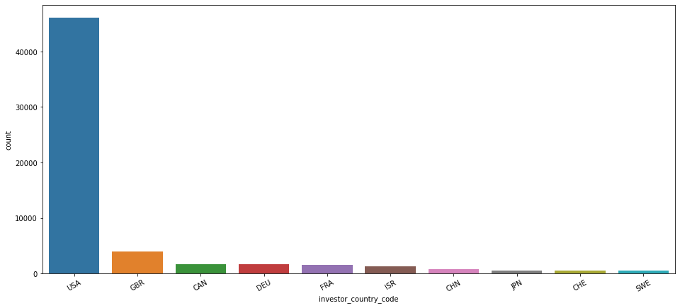

```python
plt.figure(figsize=(16,7))
g = sns.countplot(x ='investor_country_code', data = df_investments, order=df_investments['investor_country_code'].value_counts().iloc[:10].index)
plt.xticks(rotation=30)
plt.show()
```

We can see that among the countries, the US is the most represented among the investors, followed by GBR and CAN.

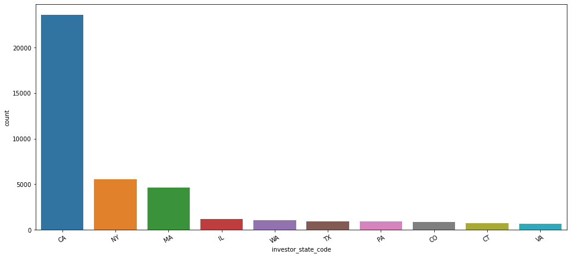

```python
plt.figure(figsize=(16,7))
g = sns.countplot(x ='investor_state_code', data = df_investments, order=df_investments['investor_state_code'].value_counts().iloc[:10].index)
plt.xticks(rotation=30)
plt.show()
```

We can see that among the states, California is the most represented among the investors followed by NY, MA and IL

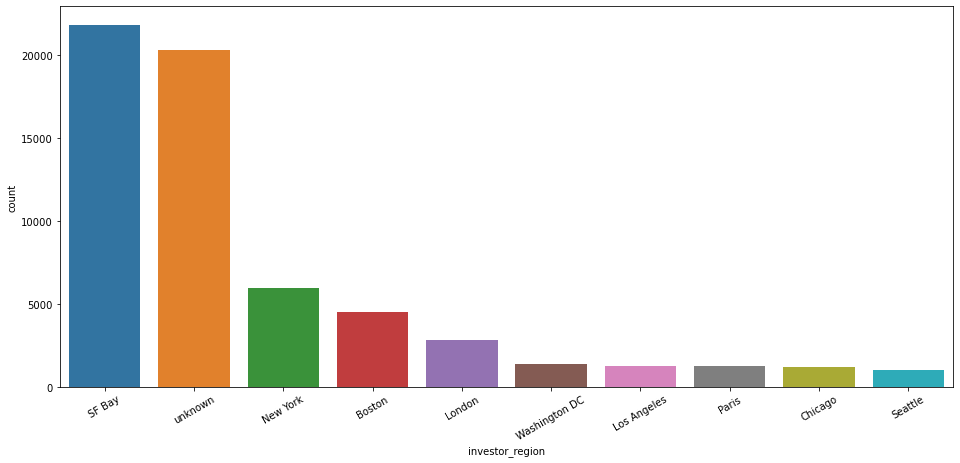

```python
plt.figure(figsize=(16,7))
g = sns.countplot(x ='investor_region', data = df_investments, order=df_investments['investor_region'].value_counts().iloc[:10].index)
plt.xticks(rotation=30)
plt.show()
```

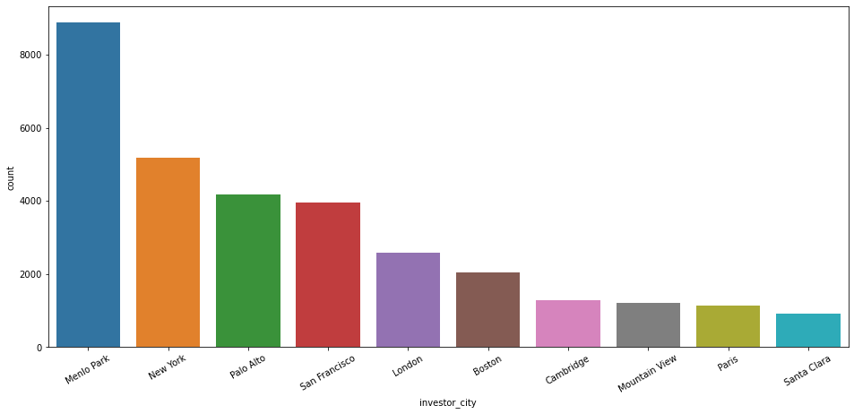

```python
plt.figure(figsize=(16,7))
g = sns.countplot(x ='investor_city', data = df_investments, order=df_investments['investor_city'].value_counts().iloc[:10].index)
plt.xticks(rotation=30)
plt.show()
```

We can see surprisingly that most of the investors come from Menlo Park and then New York and Palo Alto.

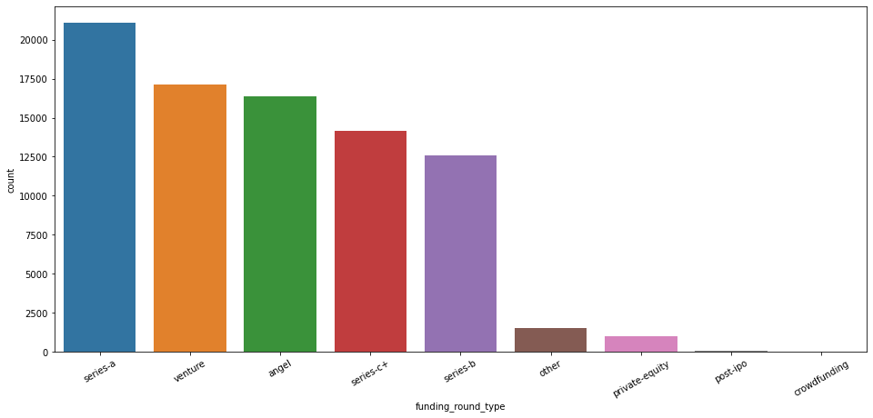

```python
plt.figure(figsize=(16,7))
g = sns.countplot(x ='funding_round_type', data = df_investments, order=df_investments['funding_round_type'].value_counts().iloc[:10].index)
plt.xticks(rotation=30)
plt.show()
```

While analysing the funding rounds we can see that most of the funding happens in series a and then venture and angel.

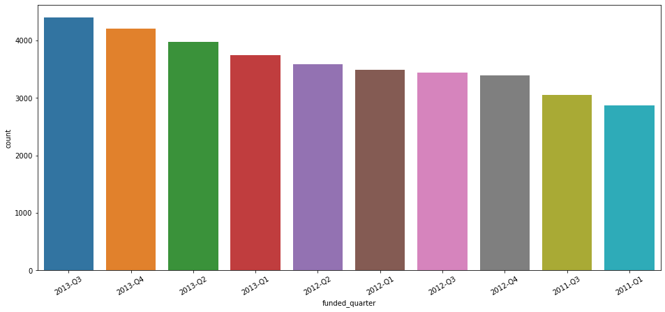

```python
plt.figure(figsize=(16,7))
g = sns.countplot(x ='funded_quarter', data = df_investments, order=df_investments['funded_quarter'].value_counts().iloc[:10].index)
plt.xticks(rotation=30)
plt.show()
```

Analysing the quarters in the dataset, we can see that most of the funding happened in 2013.

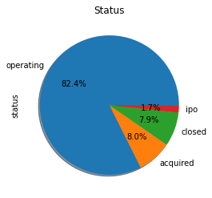

```python
plt.figure(figsize = (4,4))
df_companies.status.value_counts().plot(kind='pie',shadow=True, autopct='%1.1f%%')
plt.title('Status')
plt.show()
```

Analysing the companies we can see that most of them are operating. The second most common status is acquired and then closed

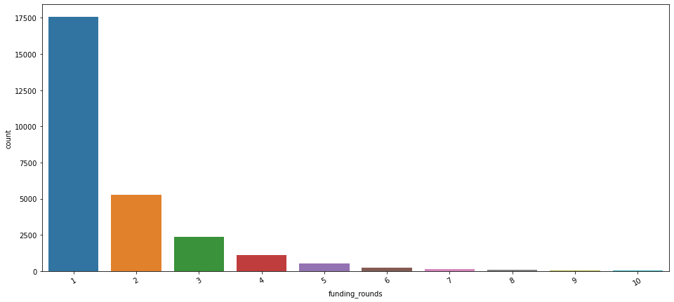

```python
plt.figure(figsize=(16,7))
g = sns.countplot(x ='funding_rounds', data = df_companies, order=df_companies['funding_rounds'].value_counts().iloc[:10].index)
plt.xticks(rotation=30)
plt.show()
```

Analysing the funding rounds of the companies we can see that most of them have had 1 funding round. But some have had more than 5 too.

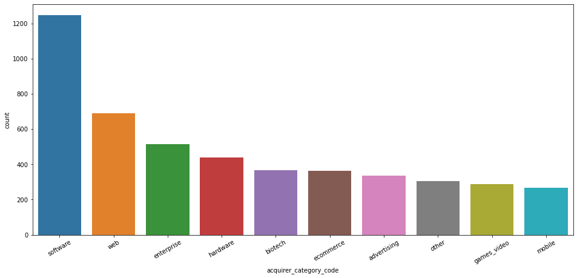

```python
plt.figure(figsize=(16,7))
g = sns.countplot(x ='acquirer_category_code', data = df_acquisitions, order=df_acquisitions['acquirer_category_code'].value_counts().iloc[:10].index)
plt.xticks(rotation=30)
plt.show()
```

Analysing the acquisitions, most of the acquirer category codes have been in software, web and enterprise as can be seen above

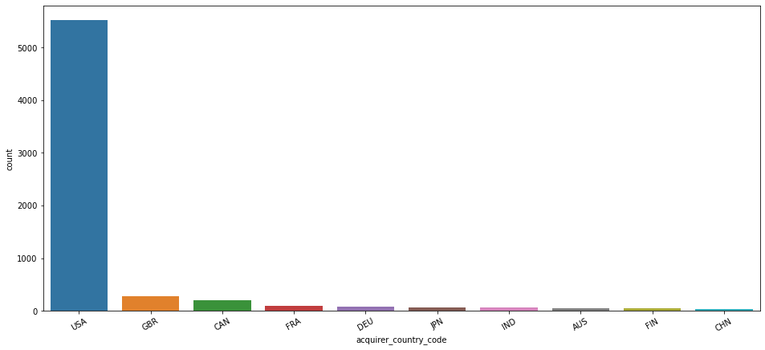

```python
plt.figure(figsize=(16,7))
g = sns.countplot(x ='acquirer_country_code', data = df_acquisitions, order=df_acquisitions['acquirer_country_code'].value_counts().iloc[:10].index)
plt.xticks(rotation=30)
plt.show()
```

Most of the acquirers are from the US, followed by GBR and then CAN

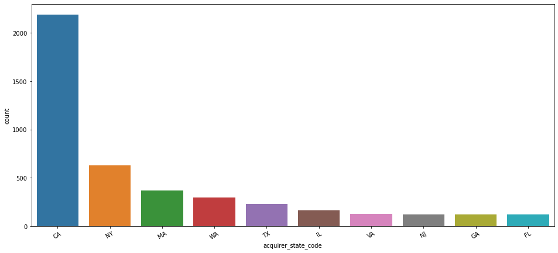

```python
plt.figure(figsize=(16,7))
g = sns.countplot(x ='acquirer_state_code', data = df_acquisitions, order=df_acquisitions['acquirer_state_code'].value_counts().iloc[:10].index)
plt.xticks(rotation=30)
plt.show()
```

We can see that most of the acquirers are in CA followed by NY, MA and then WA.

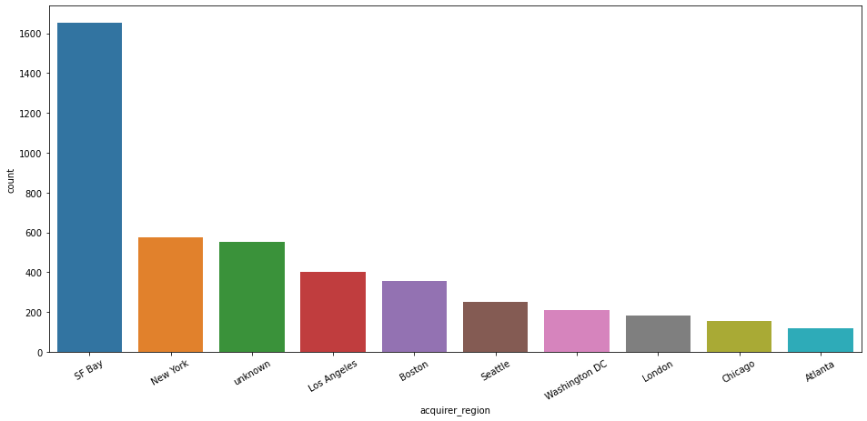

```python
plt.figure(figsize=(16,7))
g = sns.countplot(x ='acquirer_region', data = df_acquisitions, order=df_acquisitions['acquirer_region'].value_counts().iloc[:10].index)
plt.xticks(rotation=30)
plt.show()
```

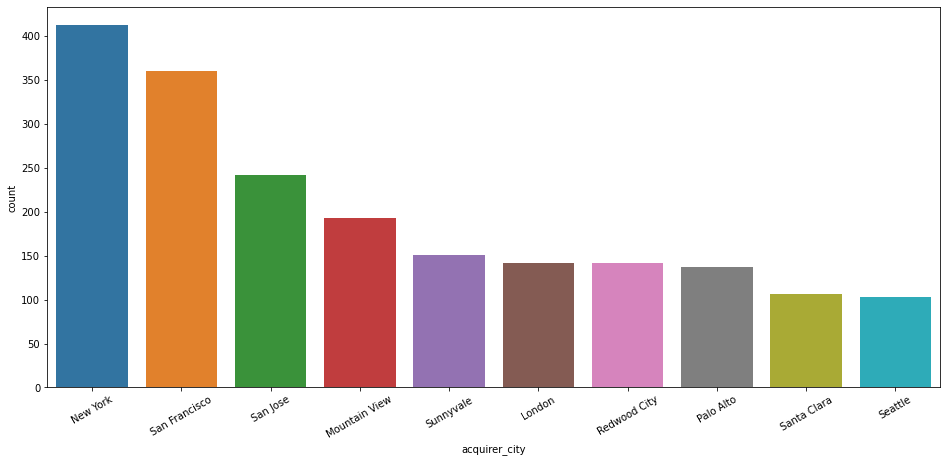

```python
plt.figure(figsize=(16,7))
g = sns.countplot(x ='acquirer_city', data = df_acquisitions, order=df_acquisitions['acquirer_city'].value_counts().iloc[:10].index)
plt.xticks(rotation=30)
plt.show()
```

We can see that most of the acquirers are from New York, San Francisco and then San Jose and then Mountain View.

```python
df_acquisitions[["acquirer_month","acquirer_day","acquirer_year"]] = df_acquisitions["acquired_at"].str.split("/",expand=True)
```

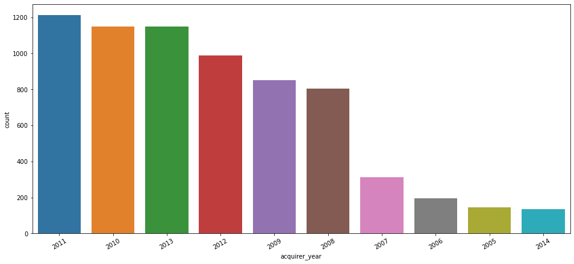

```python
plt.figure(figsize=(16,7))
g = sns.countplot(x ='acquirer_year', data = df_acquisitions, order=df_acquisitions['acquirer_year'].value_counts().iloc[:10].index)
plt.xticks(rotation=30)
plt.show()
```

We can see that most of the acquisitions happened in 2011 followed by 2010 and then 2013.

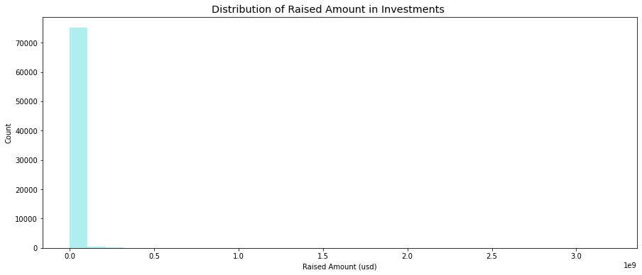

```python
plt.rcParams['figure.figsize'] = 15,6
plt.hist(df_investments['raised_amount_usd'].dropna(), bins=30,color = 'paleturquoise' )

plt.ylabel('Count')
plt.xlabel('Raised Amount (usd)')
plt.title("Distribution of Raised Amount in Investments", fontdict=None, position= [0.48,1.05], size = 'x-large')
plt.show()
```

We can see that the Distribution of Raised Amount in Investments is as above with some very high investments but mostly small ones.

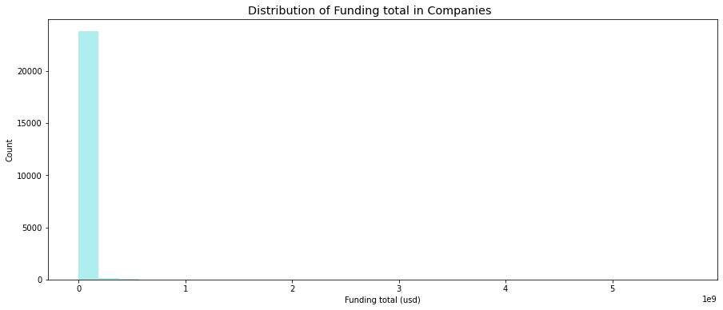

```python
plt.rcParams['figure.figsize'] = 15,6
plt.hist(df_companies['funding_total_usd'].dropna(), bins=30,color = 'paleturquoise' )

plt.ylabel('Count')
plt.xlabel('Funding total (usd)')
plt.title("Distribution of Funding total in Companies", fontdict=None, position= [0.48,1.05], size = 'x-large')
plt.show()
```

We can see that the Distribution of Funding total in Companies is as above with some very high investments but mostly small ones.

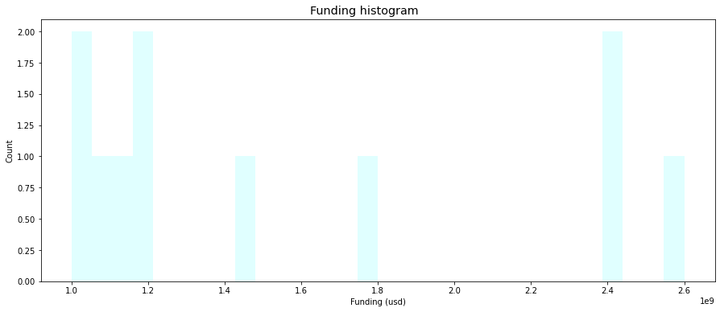

```python
plt.hist(df_companies['funding_total_usd'][(df_companies['funding_total_usd'] >= 1000000000)&(df_companies['funding_total_usd'] <= 3000000000)].dropna(), bins=30,color = 'lightcyan' )
plt.ylabel('Count')
plt.xlabel('Funding (usd)')
plt.title("Funding histogram", fontdict=None, position= [0.48,1.05], size = 'x-large')
plt.show()
```

Analysing the funding according to the companies and drawing a histogram we get the following graph.